# Exemple de manipulation de rasters avec `R` et le package `Terra`

AfroMap’R 2025

Auteur·rice

Brian Plaisant

Date de publication

2025-07-11

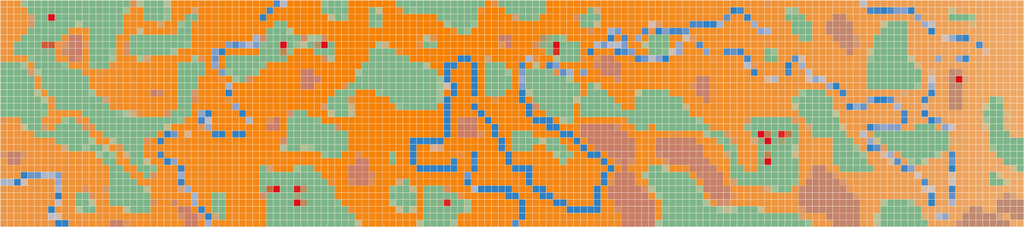

**Note**

Ce support reprend les travaux faits lors de l’école d’été GéoUniv’R 2024, qui est lui-même inspiré par les informations de ces différentes sources : [Géomatique avec R](https://rcarto.github.io/geomatique_avec_r/) (Giraud et Pecout 2024), [Analyse d’image raster (et télédétection)](https://mmadelin.github.io/sigr2021/SIGR2021_raster_MM.html) (Madelin 2021) et [Image processing and all things raster](https://nowosad.github.io/SIGR2021/workshop2/workshop2.html) (Nowosad 2021). Les données ont été adaptées au contexte ivoirien.

**Documents indispensables : Cheat sheet r-base**

Ce document est indispensable à avoir pour toutes personnes voulant commencer à apprendre le langage R.

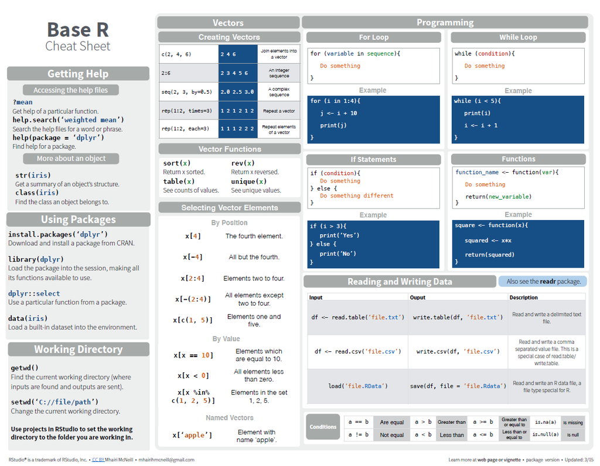

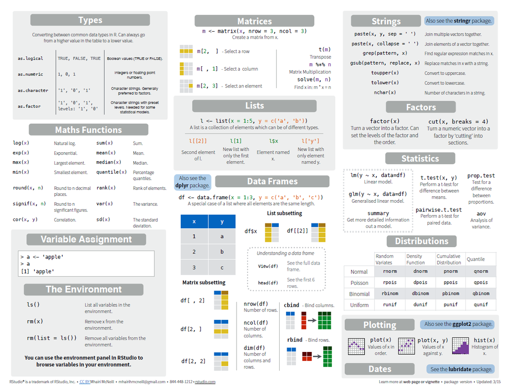

# Objectifs

- Statistique de base sur un raster
- Réaliser un profil topographique
- Afficher une image satellite en vraie et fausse couleur
- Mettre en valeur les zones humides en calculant l’“indice d’eau par différence normalisée”
- Estimer la surface en eau du lac de Kossou

# Les rasters

## Qu’est-ce qu’une donnée raster ?

Un raster est une grille, dite matrice, qui possède des lignes et des colonnes. Au croisement se trouve un pixel dans lequel se trouve une valeur numérique. Le tout peut être affiché comme une image.

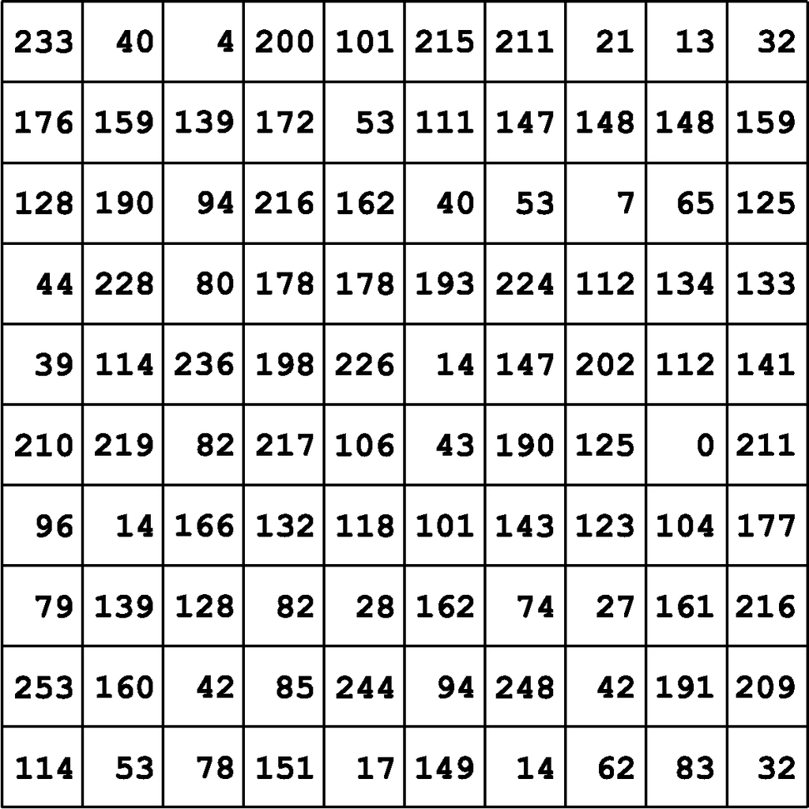

Grille dans laquelle se trouvent que des valeurs aléatoires de 0 à 255

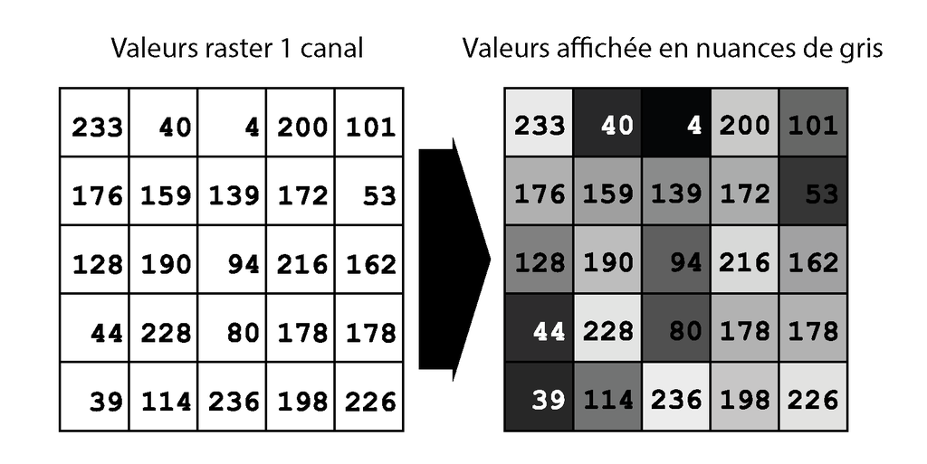

Pour chaque case a été mis une valeur de luminosité en fond

Pour obtenir des couleurs, il faut avoir trois bandes ayant des valeurs de luminosité dans le rouge, le vert, et le bleu.

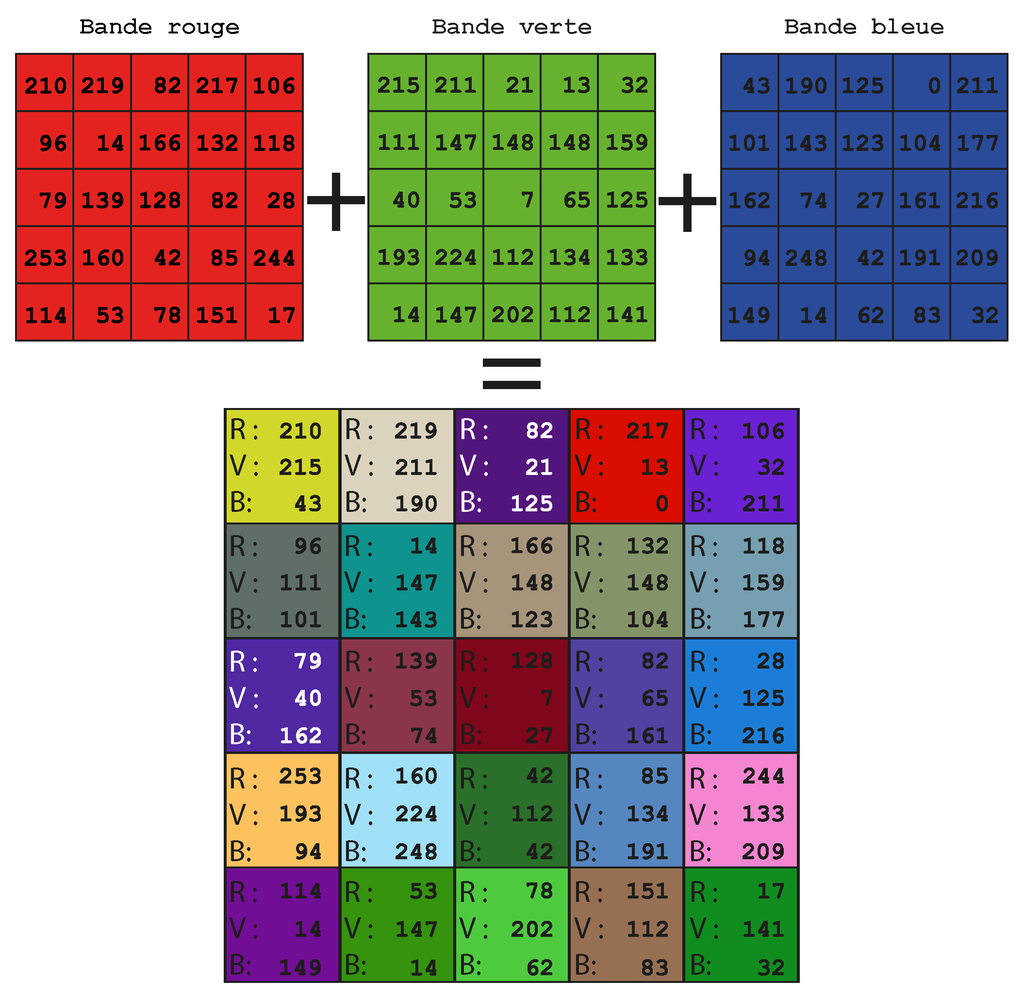

Exemple de combinaison de trois rasters ayant chacune des valeurs de luminosité

## Deux exemples de données rasters en SIG :

### Un modèle numérique de terrain

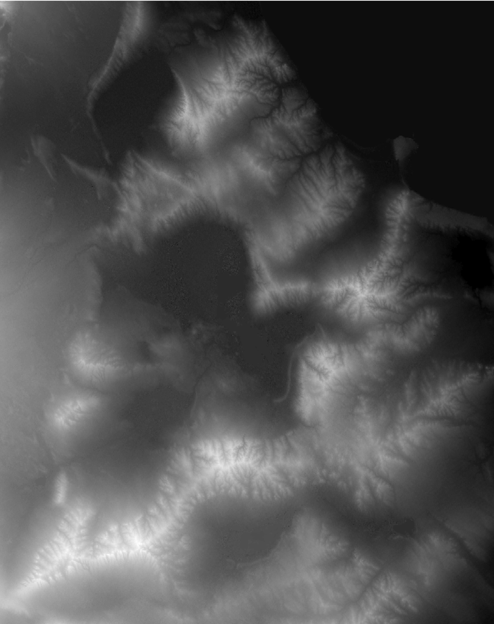

Les basses altitudes sont foncées et les hautes altitudes sont claires. Chaque pixel contient une valeur qui correspond à l’altitude moyenne du pixel.

### Une image satellite

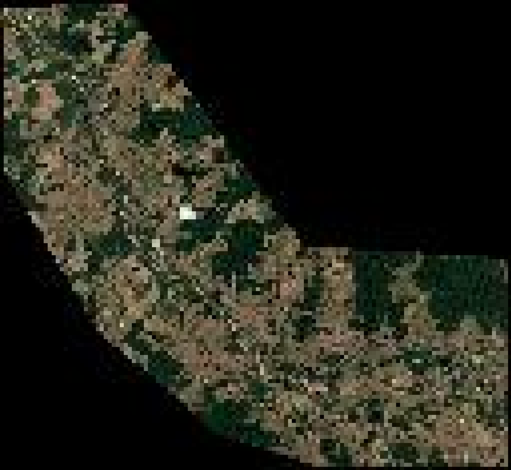

Prévisualisation d’une image prise par un satellite représentant les vraies couleurs.

# Le package

## Package utilisé

- **`terra`** : importer, manipuler et exporter des fichiers rasters. Le package possède les fonctionnalitée pour les manipulations de base des données de type vecteur.

Accès à la documentation complète du package

## Activer le package `terra`

La fonction `library()` avec le nom du package permet d’activer le package.

```r
library(terra)
```

**Comment installer le package s’il n’est pas installé**

Si vous n’avez pas ces packages, vous pouvez les installer en exécutant la ligne suivante dans la console.

```r
install.packages("terra")
```

Installer le package à partir de l’interface `rstudio` est bien sûr possible.

# Les données

## Données utilisées

- Raster
  - Modèle numérique de terrain ([OpenTopography](https://portal.opentopography.org/datasets))
  - Images Sentinel 2 du lac de Kossou contenant les bandes B02, B03, B04 et B08 ([Protail Géode du CNES](https://geodes-portal.cnes.fr))
- Vecteur
  - Polygone de la zone d’étude incluant le lac de Kossou et la ville de Bouaké
  - Polygone grossier du contour du lac de Kossou
  - Ligne coupant le lac de Kossou

## Importer des données avec `terra`

### Pour importer des objets rasters

La fonction pour importer des objets raster est `rast()` et le lien vers le fichier, quelque soit le type d’image.

#### Importation du MNT

```r
# MNT
MNT <- rast("data/raster/MNT/MNT.tif")
```

**Importer et fusionner plusieurs tuiles raster**

Les fichiers rasters peuvent être téléchargés en plusieurs morceaux, `terra` permet de les fusionner pour créer un seul et même objet.

Étape 1 : importer les fichiers

```r
MNT_nord <- rast("data/raster/MNT/MNT_N.tif")
MNT_sud <- rast("data/raster/MNT/MNT_S.tif")
```

Étape 2 : fusionner avec la fonction `merge()`

```r
MNT <- merge(MNT_nord, MNT_sud)
```

#### Importation d’un raster avec plusieurs bandes incluses

```r
RGB_PIR <-  rast("data/raster/Sentinel_2/S2_Kossou_03_05_2025.tif")
```

**Importer des images satellites en bandes séparées**

```r
# Importer les différentes bandes des images sentinel 2

# La bande bleue
bleu <- rast("data/raster/Sentinel_2/S2_Kossou_03_05_2025_B02.tif")

# La bande verte
vert <- rast("data/raster/Sentinel_2/S2_Kossou_03_05_2025_B03.tif")

# La bande rouge
rouge <- rast("data/raster/Sentinel_2/S2_Kossou_03_05_2025_B04.tif")

# La bande proche infrarouge
proche_infrarouge <- rast("data/raster/Sentinel_2/S2_Kossou_03_05_2025_B08.tif")
```

Les données sont chargées. À partir de ces bandes, nous pouvons créer une dalle ou une tuile dans le visible.

```r
# On peut créer un objet qui contient déjà les trois bandes dans le visible
image_RGB = c(bleu, vert, rouge)
```

### Importer des objets vecteurs

La ligne qui servira au transect est un objet vectoriel. On peut la charger en tant que telle avec la fonction `vect()` de `terra`. L’objet chargé est de classe `SpatVector`.

Il est aussi possible de la charger avec le package `sf` conçu pour manipuler les objets vectoriels en priorité. Pour cela, voir le module de l’école thématique portant sur les vecteurs : manipuler des objets vectoriels avec `sf`

Ici nous chargeons un objet vectoriel au format `.shp`

```r
# Import du fichier de ligne
ligne <- vect("data/geom/ligne.shp")

class(ligne)
```

```
[1] "SpatVector"
attr(,"package")
[1] "terra"
```

Il est aussi possible de charger des objets au format `.gpkg`. Nous chargeons le masque qui servira aux prochaines opérations.

```r
# Charger un gpkg
zone_etude <- vect("data/geom/lac_kossou.gpkg")
```

**Obtenir des informations sur nos rasters**

Noter le nom de l’objet permet d’obtenir des informations sur lui-même

```r
#Affichage des métadonnées
RGB_PIR
```

```
class       : SpatRaster
size        : 13524, 7283, 4  (nrow, ncol, nlyr)
resolution  : 10, 10  (x, y)
extent      : 836950, 909780, 746770, 882010  (xmin, xmax, ymin, ymax)
coord. ref. : WGS 84 / UTM zone 29N (EPSG:32629)
source      : S2_Kossou_03_05_2025.tif
names       : T29NRH_~701_B02, T29NRH_~701_B03, T29NRH_~701_B04, T29NRH_~701_B08
min values  :            1540,            1627,            1245,            1541
max values  :           17789,           17728,           20180,           22221
```

[output not shown]

# Pratique : trouvons le lac de Kossou

## Première méthode : les statistiques

Hypothèse : L’altitude du niveau de l’eau devrait être la même sur toute la surface du lac. Dans un MNT, cela se traduirait par une surreprésentation des valeurs de pixel ayant l’altitude du lac.

### Les objets utilisés

Pour cette première méthode, nous aurons besoin que du modèle numérique de terrain nommé `MNT`

### Utilisons les fonctions statistiques de base que nous propose `R`

Essayons `summary()`

```r
summary(MNT)
```

```
     DEM_N
 Min.   : 80.92
 1st Qu.:194.68
 Median :221.52
 Mean   :227.56
 3rd Qu.:256.06
 Max.   :611.83
```

Les informations de `summary()` sont limitées malheureusement. Essayons de visualiser l’histogramme avec `hist()`.

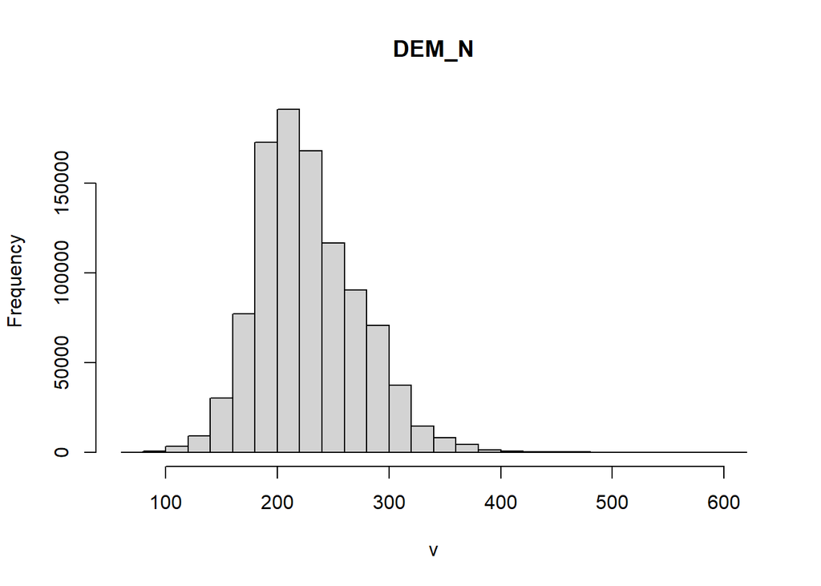

```r
hist(MNT)
```

Essayons de rajouter des classes pour voir si nous voyons un peu plus de details avec paramètre `nclass = 100`.

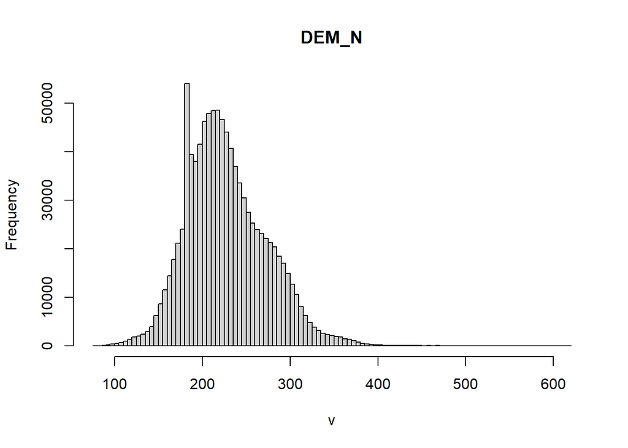

```r
hist(MNT, nclass = 100)
```

Et avec 200 classes ?

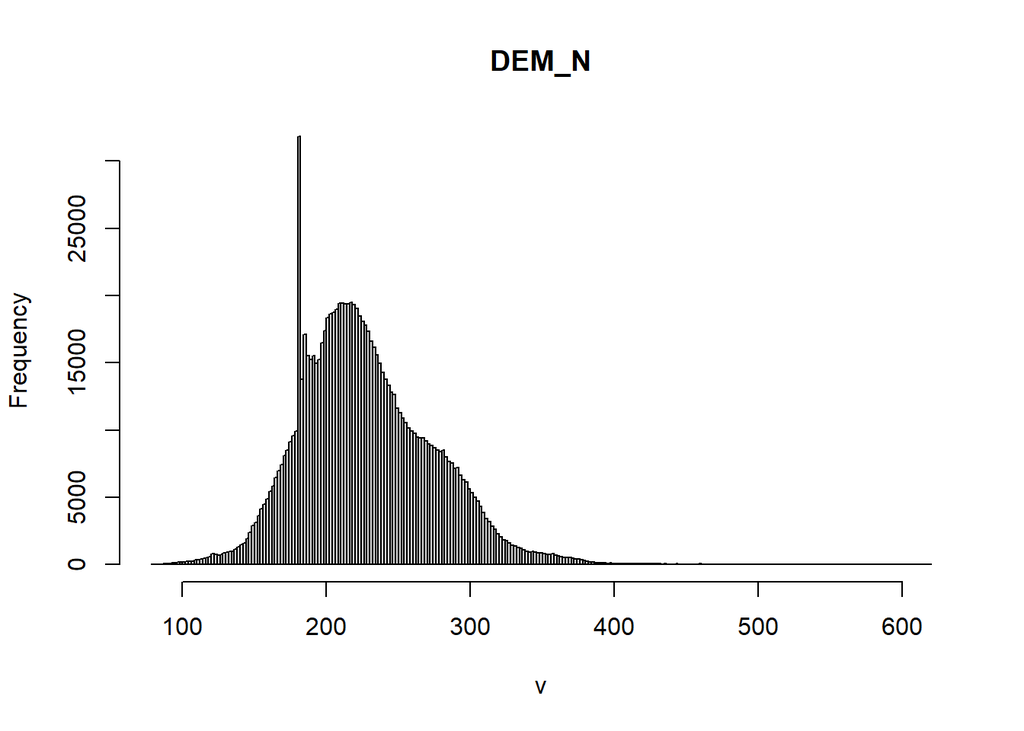

```r
hist(MNT, nclass = 200)
```

Essayons d’être plus précis en étudiant la fréquence des pixels avec la fonction `freq()`.

```r
tab <- freq(MNT)
tab[1:10,] # Permet d'afficher les lignes de la première à la dixième.
```

```
   layer value count
1      1    80    41
2      1    81    71
3      1    82   179
4      1    83   185
5      1    84   223
6      1    85   290
7      1    86   307
8      1    87   363
9      1    88   480
10     1    89   568
```

La fonction `freq()` a créé une table avec trois colonnes, le nom de la couche concerné, la valeur et le nombre de pixels ayant cette valeur.

```r
tab[tab[,3] == max(tab[,3]),]
```

[output not shown]

**Rappel sur la manipulation des tableaux**

La sélection d’objets peut se faire en `r-base` avec les crochets. Dans une table à deux dimensions, la sélection se fait suivant cette logique `objet[ligne, colonne]`.

```r
tab[40,3] # La valeur à la ligne 40 et la colonne 3.
```

```
[1] 5338
```

Pour sélectionner les valeurs d’une colonne entière ou d’une ligne entière, il suffit de ne pas préciser la ligne ou la colonne.

```r
tab[40,] # Visualisation de la ligne 40 (Le résultat avec uniquement la ligne voulue)
```

```
   layer value count
40     1   119  5338
```

```r
tab[,2] # Visualisation de la colonne 2 (le résultat est un vecteur)
```

```
  [1]  80  81  82  83  84  85  86  87  88  89  90  91  92  93  94  95  96  97
 [19]  98  99 100 101 102 103 104 105 106 107 108 109 110 111 112 113 114 115
 [37] 116 117 118 119 120 121 122 123 124 125 126 127 128 129 130 131 132 133
 [55] 134 135 136 137 138 139 140 141 142 143 144 145 146 147 148 149 150 151
 [73] 152 153 154 155 156 157 158 159 160 161 162 163 164 165 166 167 168 169
 [91] 170 171 172 173 174 175 176 177 178 179 180 181 182 183 184 185 186 187
[109] 188 189 190 191 192 193 194 195 196 197 198 199 200 201 202 203 204 205
[127] 206 207 208 209 210 211 212 213 214 215 216 217 218 219 220 221 222 223
[145] 224 225 226 227 228 229 230 231 232 233 234 235 236 237 238 239 240 241
[163] 242 243 244 245 246 247 248 249 250 251 252 253 254 255 256 257 258 259
[181] 260 261 262 263 264 265 266 267 268 269 270 271 272 273 274 275 276 277
[199] 278 279 280 281 282 283 284 285 286 287 288 289 290 291 292 293 294 295
[217] 296 297 298 299 300 301 302 303 304 305 306 307 308 309 310 311 312 313
[235] 314 315 316 317 318 319 320 321 322 323 324 325 326 327 328 329 330 331
[253] 332 333 334 335 336 337 338 339 340 341 342 343 344 345 346 347 348 349
```

[output cut: 16 more lines]

Maintenant que nous connaissons la valeur la plus fréquente, essayons de créer un raster avec vrai/faux avec celle-ci.

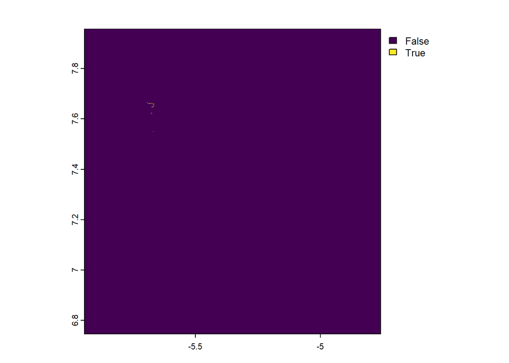

```r
plot(MNT == 182)
```

Le résultat est peu convaincant, essayons de créer un raster avec une marge de plus ou moins 1 mètre avec l’opérateur logique `&`.

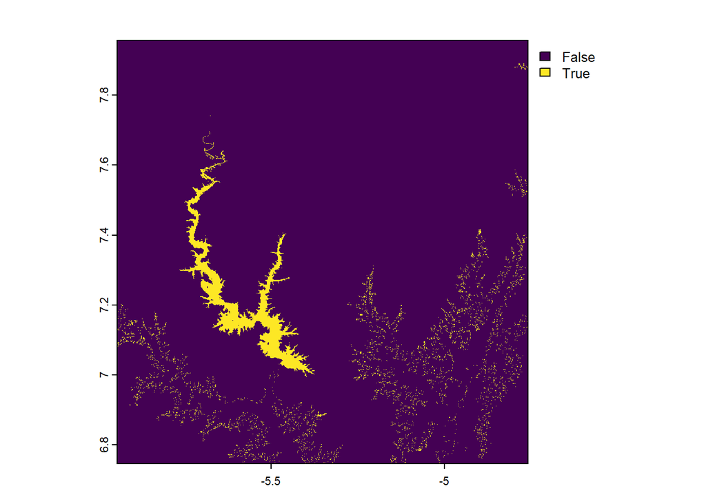

```r
plot(MNT > 181  & MNT  < 183)
```

Essayons de créer une image avec notre MNT avec le lac dans une seule et même couleur.

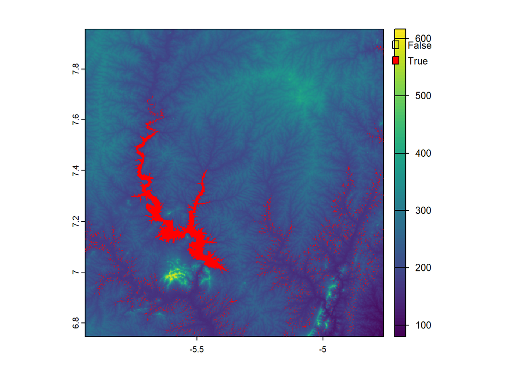

```r
kossou <- MNT > 181  & MNT  < 183

plot(MNT)
plot(kossou, col = c(rgb(255, 255, 255, alpha = 0, maxColorValue = 255), "red"), add = T)
```

**Explication de col = c(rgb(255, 255, 255, alpha = 0, maxColorValue = 255), ‘red’)**

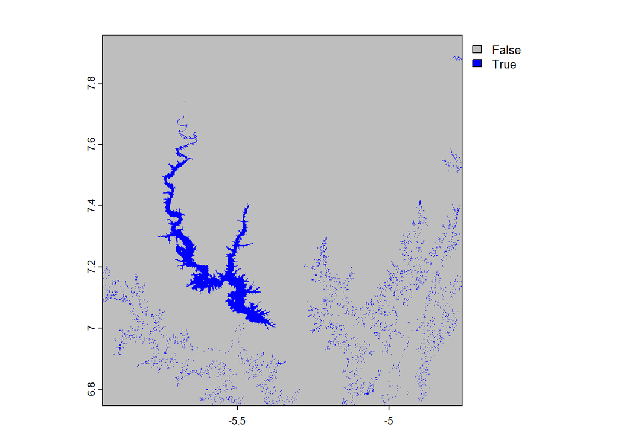

```r
plot(kossou,  col = c('gray', 'blue'))
```

Mais on peut afficher une couleur en transparence avec la fonction `rgb()`. Là, il va falloir renseigner les valeurs dans le rouge `r`, le vert `g` et le bleu `b`. À cela, on ajoute le paramètre `maxColorValue` qui permet de définir la valeur maximale en termes de luminosité. Et enfin, le paramètre `alpha` permet de définir l’opacité, 0 étant la valeur minimale.

Si on définit 1, 100 ou x valeurs comme valeur maximale au lieu de 255, ça fonctionne aussi.

## Deuxième méthode : la coupe topographique

L’idée de cette méthode est de voir où se trouve le lac sur un transect qui coupe en diagonale notre image raster.

### Les objets utilisés

Pour réaliser une coupe topographique sur `terra`, seuls le modèle numérique de terrain et la courbe sont nécessaires, ligne vectorielle chargée plus haut dans la Section 4.2.2.

### Visualisation

Comme pour toutes autres données, plot permet de visualiser les données rasters et vecteurs avec la fonction `plot()`.

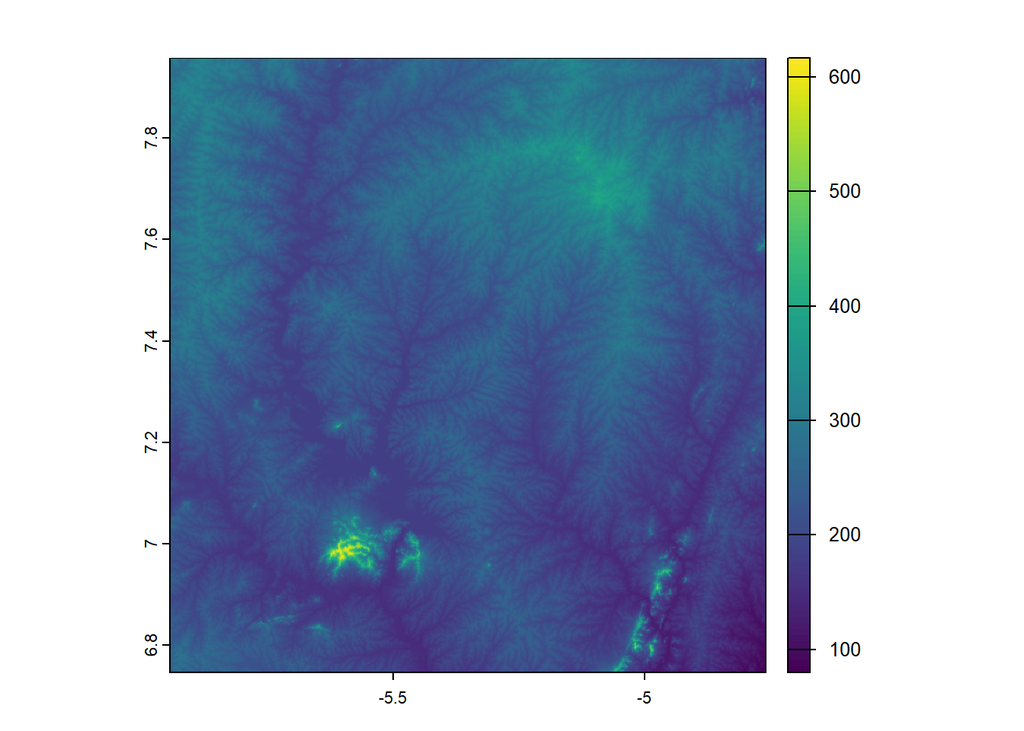

```r
plot(MNT)
```

Affichage de la ligne par-dessus avec le paramètre `add = TRUE` dans la fonction `plot()`

```r
plot(ligne, add = T)
```

```
Error in graphics::plot.xy(g, type = "l", lty = lty, col = col, lwd = lwd, : plot.new has not been called yet
```

Dans le cas où les données ne se superposent pas, nous pouvons vérifier si les données ont la même projection avec la fonction `same.crs()` et il est possible de reprojeter une donnée avec `project()` et utiliser `crs()` pour définir la projection choisie selon une autre couche.

```r
same.crs(MNT, ligne)
```

```
[1] FALSE
```

Les objets n’ont pas la même projection, pour les connaître regardons leurs métadonnées

```r
MNT
```

```
class       : SpatRaster
size        : 4361, 4267, 1  (nrow, ncol, nlyr)
resolution  : 0.0002777778, 0.0002777778  (x, y)
extent      : -5.944028, -4.75875, 6.74625, 7.957639  (xmin, xmax, ymin, ymax)
coord. ref. : lon/lat WGS 84 (EPSG:4326)
source(s)   : memory
varname     : MNT_N
name        :     DEM_N
min value   :  79.55703
max value   : 619.54944
```

```r
ligne
```

```
 class       : SpatVector
 geometry    : lines
 dimensions  : 1, 1  (geometries, attributes)
 extent      : 852958.3, 942323.6, 769155.2, 848974.8  (xmin, xmax, ymin, ymax)
 source      : ligne.shp
 coord. ref. : WGS 84 / UTM zone 29N (EPSG:32629)
 names       :    id
 type        : <num>
 values      :   NaN
```

Le raster est en WGS 84 EPSG:4326, et la ligne en WGS 84 / UTM zone 29N EPSG:32629.

Projetons le raster pour qu’il corresponde à la ligne avec la fonction `project()` et la fonction `crs()` permettant de récupérer le crs d’un objet.

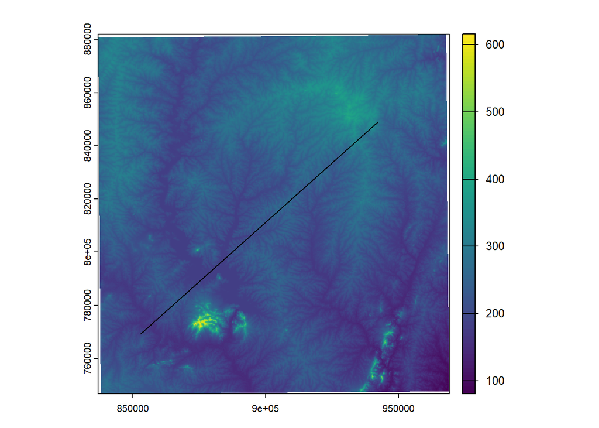

```r
MNT <- project(x = MNT, crs(ligne))

# Réessayons d'afficher la ligne sur le MNT
plot(MNT)
plot(ligne, add = T)
```

Si ce n’est pas assez visible, les paramètres `col = "RED"` et `lwd = 5` vont nous aider.

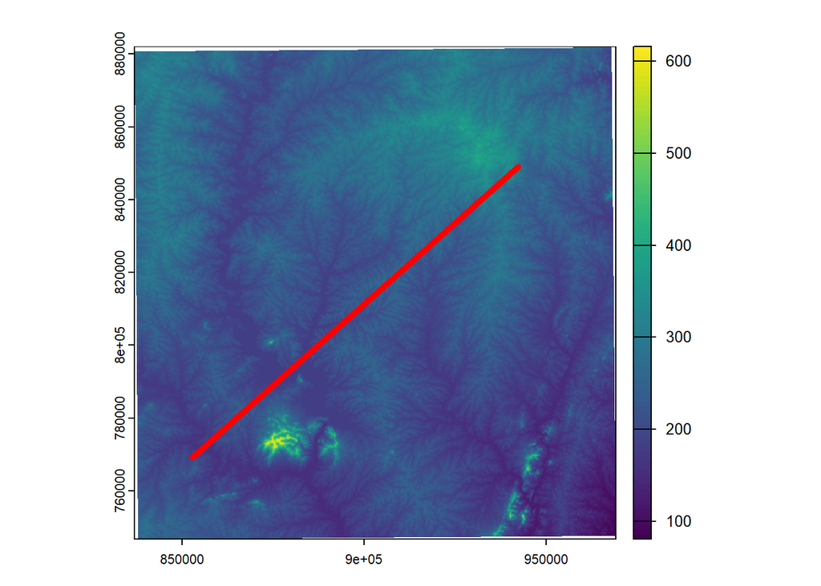

```r
plot(MNT)
plot(ligne, add = T, col = "RED", lwd = 5)
```

### Création de la courbe topographique selon la ligne

La fonction `extact()` permet d’extraire toutes les valeurs que rencontre la ligne sur le MNT.

```r
transect_points <- extract(x = MNT, y = ligne)
```

**Point sur les objets en sortie**

Pour savoir le type d’objet que nous avons, `class()` permet de nous aider.

```r
# Interrogation du type d'objet
class(transect_points)
```

```
[1] "data.frame"
```

L’objet récupéré est de type `data.frame`. La fonction `head()` permet d’afficher les premières lignes d’une `data.frame` et la fonction `rnow()` pour avoir le nombre de lignes.

```r
# Visualisation des premières lignes de la df
head(transect_points)
```

```
  ID    DEM_N
1  1 309.7225
2  1 307.9082
3  1 311.3893
4  1 309.2067
5  1 312.0819
6  1 310.1726
```

```r
# Nombre de ligne
nrow(transect_points)
```

```
[1] 5504
```

On a intersecté 5504 cellules.

Visualisons notre coupe topographique :

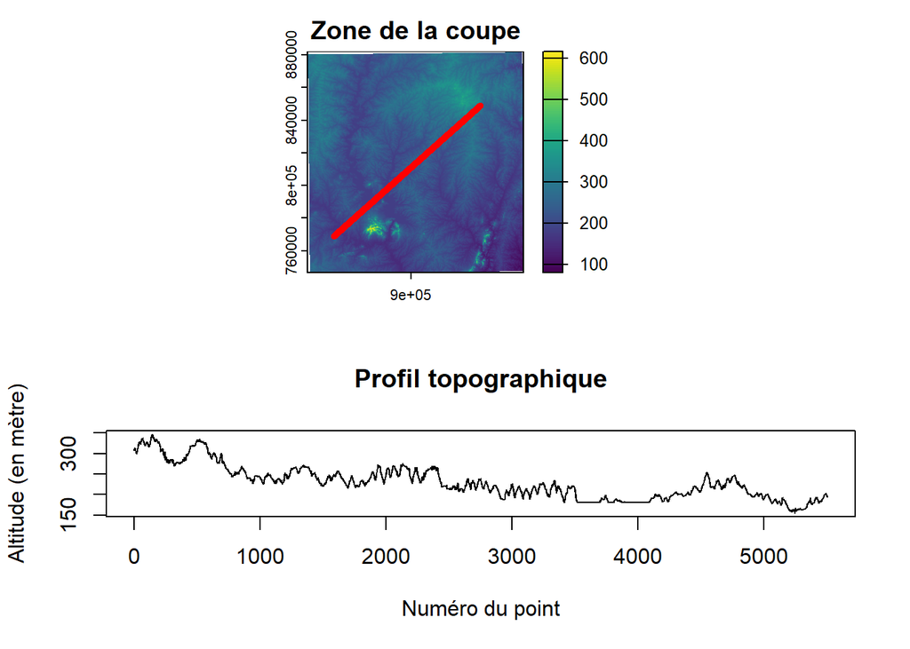

```r
# Affichons le MNT et le profil sur un même plot
par(mfrow = c(2, 1)) # permet de jouxter deux figures (deux lignes, une colonne).

plot(MNT, main =  "Zone de la coupe")
plot(ligne, add = T, col = "RED", lwd = 5)


plot(x = 1:nrow(transect_points), #Le premier objet en x est
     y = transect_points[,2],
     type = 'line',
     xlab = "Numéro du point",
     ylab = "Altitude (en mètre)")
title("Profil topographique")
```

**Explication du `plot` de la courbe**

- `par(mfrow = c(2, 1))` : Permet de dire à R que l’on veut créer une figure avec plusieurs objets. Dans le `c(x, y)`, ‘x’ renseigne le nombre de lignes, et le `y` le nombre de colonnes.
- `plot(MNT)` : permet d’afficher le MNT comme premier objet avec un titre `main = "Zone de la coupe"`.
- `plot(ligne, add = T, col = "RED", lwd = 5)` : permet d’ajouter à la figure précédente avec `add = TRUE` la ligne `ligne` en couleur rouge `col = "RED"`, taille 5 `lwd = 5`.

Pour le graphique, ce que nous voulons afficher, c’est une ligne qui rejoint chaque valeur présente dans le tableau issue de la fonction `extract()`. Pour ce tableau, nous avons besoin de définir le `x` et le `y`, la fonction `plot()` va croiser les deux suites de nombres.

**Note utile : mesurer la longueur des différents objets**

Suivant le type d’objet (connaissable avec la fonction `classe()`),

voici comment les mesurer :

`ncol()` : permet de connaître le nombre de colonnes dans une table

```r
# Nombre de colonnes
ncol(MNT)
```

```
[1] 4299
```

```r
ncol(transect_points)
```

```
[1] 2
```

`nrow()` : permet de connaître le nombre de lignes dans une table

```r
#Nombre de ligne
nrow(MNT)
```

```
[1] 4399
```

```r
nrow(transect_points)
```

```
[1] 5504
```

`lenght()` : permet de connaître le nombre d’objets dans un vecteur (c())

```r
# Nombre d'objets dans un vecteur
length(transect_points$DEM_N)
```

```
[1] 5504
```

```r
length(c(4, 8, 9, 4, 2, 3))
```

```
[1] 6
```

`nlyr()` : permet de connaître le nombre de couches que contient un SpatRaster

```r
# Nombre de couches dans un objet SpatRaster
nlyr(RGB_PIR)
```

```
[1] 4
```

`ncell()` : permet de connaître le nombre de pixels dans un raster

```r
# Nombre de pixels
ncell(MNT)
```

```
[1] 18911301
```

## Troisième méthode : les images satellites

L’objectif est d’identifier et isoler le lac à partie d’images satellites.

### Les objets utilisés

Nous utiliserons l’objet `RGB_PIR` qui est une image Sentinel 2.

Affichage des métadonnées pour mieux comprendre notre image.

```r
RGB_PIR
```

```
class       : SpatRaster
size        : 13524, 7283, 4  (nrow, ncol, nlyr)
resolution  : 10, 10  (x, y)
extent      : 836950, 909780, 746770, 882010  (xmin, xmax, ymin, ymax)
coord. ref. : WGS 84 / UTM zone 29N (EPSG:32629)
source      : S2_Kossou_03_05_2025.tif
names       : T29NRH_~701_B02, T29NRH_~701_B03, T29NRH_~701_B04, T29NRH_~701_B08
min values  :            1540,            1627,            1245,            1541
max values  :           17789,           17728,           20180,           22221
```

### Visualiser des images satellites

#### Visualiser une bande seule

On peut visualiser les bandes une par une avec la fonction `plot()` en r-base.

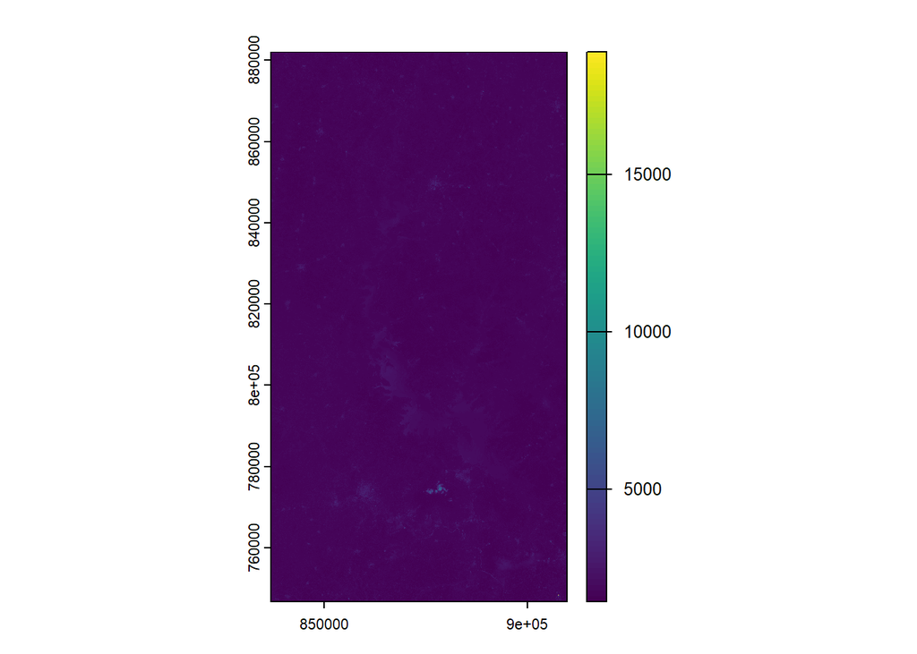

```r
# La bande nommée B04 dans l'image à quatre canaux
plot(RGB_PIR$T29NRH_20250503T103701_B04)
```

Depuis l’objet `RGB_PIR` on affiche la bande proche infrarouge avec son index

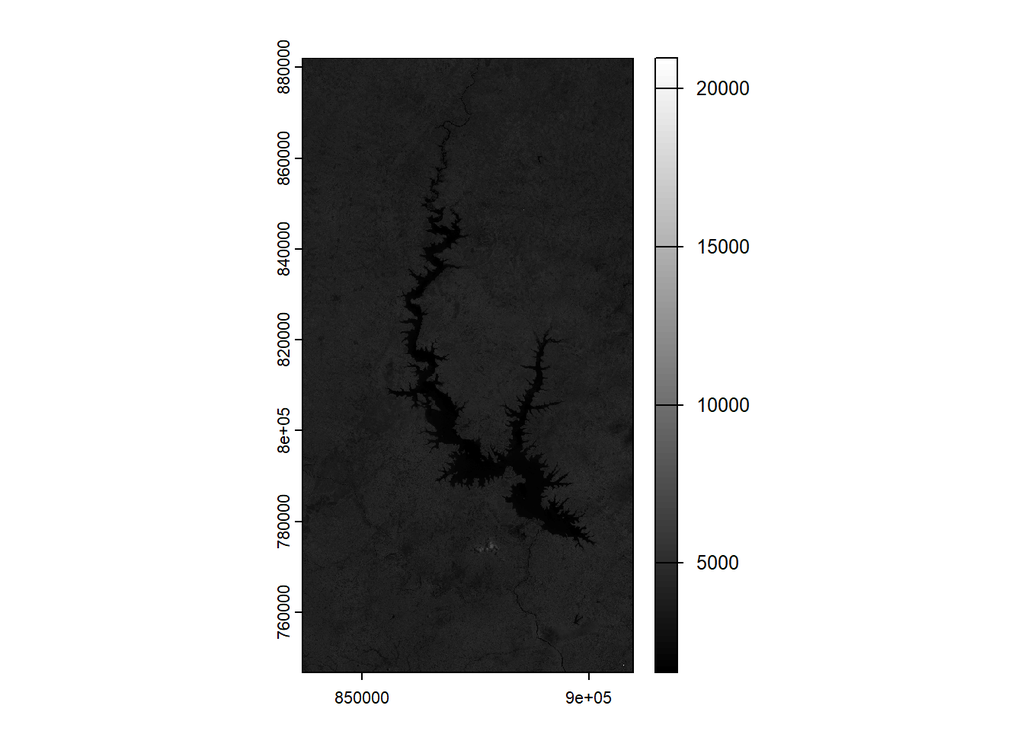

```r
# Le canal numéro 4 de l'image à 4 bande, soit le proche infrarouge ('col = grey(0:100/100)' permet de mettre la bande en noir et blanc)
plot(RGB_PIR[[4]], col = grey(0:100/100))
```

#### Visualiser plusieurs bandes en même temps

Pour visualiser plusieurs bandes en même temps, on utilise la fonction `plotRGB()` du package `terra`.

```r
#On essaye d'afficher l'image

try(plotRGB(RGB_PIR))
```

```
Error in grDevices::rgb(RGB[, 1], RGB[, 2], RGB[, 3], alpha = alpha, maxColorValue = scale) :
  l'intensité de couleur 1639, hors intervalle 0:255
```

La visualisation d’un raster multibande nécessite de connaître nos images.

Ce message d’erreur est dû au fait que les valeurs des pixels ne sont pas dans une plage de 0 à 255.

Connaître les valeurs min et max avec la fonction `minmax()` permet de renseigner la plage d’affichage des pixels.

```r
valeurs_min_et_max <- minmax(RGB_PIR)
max(valeurs_min_et_max[2,])
```

```
[1] 22221
```

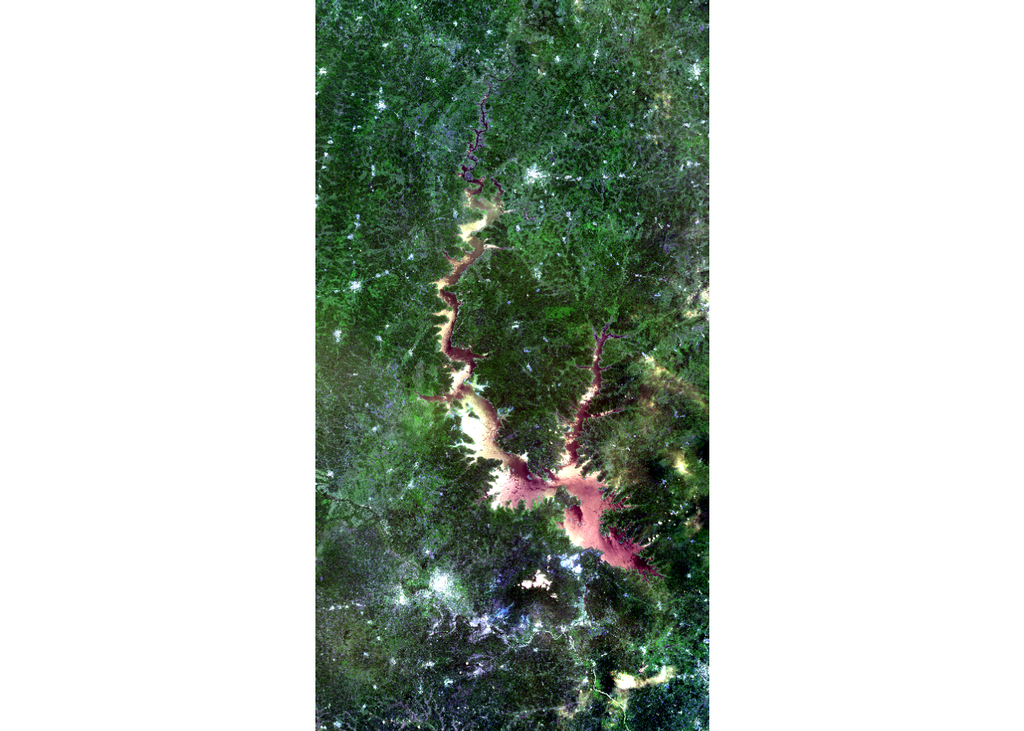

```r
plotRGB(RGB_PIR, maxColorValue  = max(valeurs_min_et_max[2,]), stretch="lin")
```

```r
#Affichage à partir de l'index
plotRGB(RGB_PIR, r = 3, g = 2, b = 1,  maxColorValue  = max(valeurs_min_et_max[2,]), stretch="lin")
```

Visualiser une image multibande depuis des objets distincts

```r
# Pour afficher une image en créant un raster multibande pour la commande même
plotRGB(x = c(rouge, vert, bleu),  maxColorValue = max(minmax(c(bleu, vert, rouge))[2,]), stretch = "lin")
```

Visualiser une image multibande depuis un objet contenant toutes les bandes.

Ici on précise la couleur de chaque bande pour obtenir une image en vraies couleurs.

```r
# Pour afficher le spectre du visible à partir de l'image multicanal. On définit les couleurs que l'on veut attribuer à chaque nom de bande.
plotRGB(RGB_PIR, r = "T29NRH_20250503T103701_B04", g="T29NRH_20250503T103701_B03", b="T29NRH_20250503T103701_B02",  maxColorValue = max(minmax(RGB_PIR)[2,]), stretch="lin")
```

[output not shown]

Ici en fausse couleur, qui permet de mettre en valeur l’**activité chlorophyllienne**, la végétation (pixels vers le rouge) :

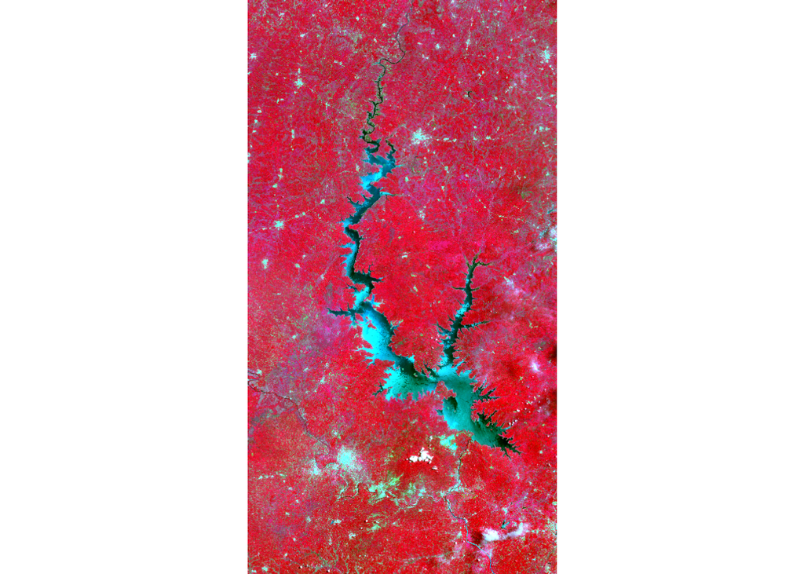

```r
# En fausse couleur
plotRGB(RGB_PIR, r = "T29NRH_20250503T103701_B08", g="T29NRH_20250503T103701_B04", b="T29NRH_20250503T103701_B03",  maxColorValue  = max(minmax(RGB_PIR)[2,]), stretch="lin")
```